# Fast Python

> Getting Started with Python

Kuo, Yao-Jen yaojenkuo@datainpoint.com from [DATAINPOINT](https://www.datainpoint.com/)

## Why do we want to learn Python?

## Simply put, we want to use Python to tackle modern data science applications.

## What is modern data science?

> Modern data science is a huge field, it invovles applications and tools like importing, tidying, transformation, visualization, modeling, and communication. Surrounding all these is programming.

[figure not shown]

Source: [R for Data Science](https://r4ds.had.co.nz/)

## Apparently, Python is gonna be our choice of "Program".

## Python: the programming language

> Python is a clear and powerful object-oriented programming language.

Source: https://www.python.org/

## Python: the gigantic snake and its relatives

- Python: the programming language itself
- Anaconda: the data science total solution
- Reticulate: the Python and R interface package

## Python is a general-purposed language that is extremely powerful and popular among many applications

- Automation
- Databases
- Analytics
- Graphical user interfaces
- Machine learning
- Web frameworks
- Web scraping
- ...etc.

## How does Python do that?

Simply put: third party libraries.

## Which third party library makes Python the go-to choice for data science?

- NumPy
- Pandas
- Matplotlib
- Scikit-Learn
- TensorFlow
- PyTorch
- ...etc.

## Why Python?

Let's review 2 questions in [2020 Kaggle ML & DS Survey](https://www.kaggle.com/c/kaggle-survey-2020)

- Q7: What programming languages do you use on a regular basis?
- Q8: What programming language would you recommend an aspiring data scientist to learn first?

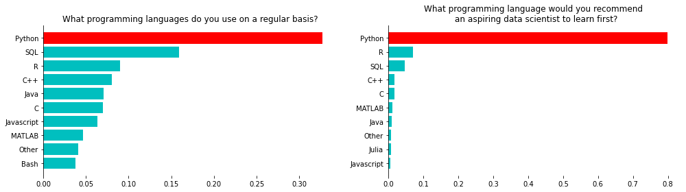

```python
plot_ans(ans_7, ans_8)
```

## If we focus on Data Analysts' responses

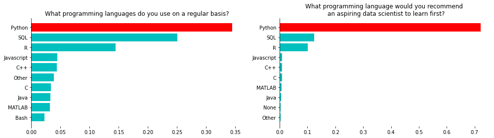

```python
plot_ans(ans_7, ans_8)
```

## Python in TIOBE Index

Source: https://www.tiobe.com/tiobe-index/

## Python in Stack Overflow 2020 Developer Survey

Source: https://insights.stackoverflow.com/survey/2020

## Python in Stack Overflow Trends

[figure not shown]

Source: [Stack Overflow Trends](https://insights.stackoverflow.com/trends?tags=java%2Cc%2Cc%2B%2B%2Cpython%2Cc%23%2Cvb.net%2Cjavascript%2Cassembly%2Cphp%2Cperl%2Cruby%2Cswift%2Cr%2Cobjective-c)

## Given Python is a general-purposed programming language

There are variuos ways setting up a Python development environement depending on:

- The operating system
- The Python interpreter
- The Integrated Development Environment
- The package/environment manager

## Even among data analysts, everyone has its own favorite flavour

[figure not shown]

Source: https://giphy.com/

## The best practice so far for a data analyst is Python interpreter + Jupyter

Well...definitely for everyone.

- [I don't like notebooks](https://youtu.be/7jiPeIFXb6U)
- [I Like Notebooks](https://youtu.be/9Q6sLbz37gk)

## A few Python programs to try on first

- Hello World!
- Zen of Python

## How to run Python scripts inside a Jupyter Notebook(with the extension of `.ipynb`)?

- Cell -> Run Cells
- Shift + Enter
- Kernel -> Restart & Run All

## Hello World!

```python
print("Hello, World!") # Cell -> Run Cells
```

```
Hello, World!
```

## Zen of Python

Long time Pythoneer Tim Peters) succinctly channels the BDFL's guiding principles for Python's design into 20 aphorisms, only 19 of which have been written down.

```python
import this # Cell -> Run Cells
```

```
The Zen of Python, by Tim Peters

Beautiful is better than ugly.
Explicit is better than implicit.
Simple is better than complex.
Complex is better than complicated.
Flat is better than nested.
Sparse is better than dense.
Readability counts.
Special cases aren't special enough to break the rules.
Although practicality beats purity.
Errors should never pass silently.
Unless explicitly silenced.
In the face of ambiguity, refuse the temptation to guess.
There should be one-- and preferably only one --obvious way to do it.
Although that way may not be obvious at first unless you're Dutch.
Now is better than never.
Although never is often better than *right* now.
If the implementation is hard to explain, it's a bad idea.
If the implementation is easy to explain, it may be a good idea.
Namespaces are one honking great idea -- let's do more of those!
```

## My favorite one would be:

> Now is better than never.

How about yours?

## Functions

`print()` and `input()` are so-called **built-in** functions in Python.

## What is a function

> A function is a named sequence of statements that performs a computation, either mathematical, symbolic, or graphical. When we define a function, we specify the name and the sequence of statements. Later, we can call the function by name.

## How do we analyze a function?

- function name
- inputs and arguments, if any
- sequence of statements
- outputs, if any

## Take bubble tea shop for instance

[figure not shown]

Source: Google Search

## What is a built-in function?

> A pre-defined function, we can call the function by name without defining it.

## How many built-in functions are available for us?

- `print()`
- `input()`
- `help()`
- `type()`
- ...etc.

Source: https://docs.python.org/3/library/functions.html

## Get HELP with `help()`

```python
help(print)
```

```
Help on built-in function print in module builtins:

print(...)
    print(value, ..., sep=' ', end='\n', file=sys.stdout, flush=False)

    Prints the values to a stream, or to sys.stdout by default.
    Optional keyword arguments:
    file:  a file-like object (stream); defaults to the current sys.stdout.
    sep:   string inserted between values, default a space.
    end:   string appended after the last value, default a newline.
    flush: whether to forcibly flush the stream.
```

```python
help(input)
```

```
Help on method raw_input in module ipykernel.kernelbase:

raw_input(prompt='') method of ipykernel.ipkernel.IPythonKernel instance
    Forward raw_input to frontends

    Raises
    ------
    StdinNotImplentedError if active frontend doesn't support stdin.
```

```python
help(type)
```

```
Help on class type in module builtins:

class type(object)
 |  type(object_or_name, bases, dict)
 |  type(object) -> the object's type
 |  type(name, bases, dict) -> a new type
 |  Methods defined here:
 |  __call__(self, /, *args, **kwargs)
 |      Call self as a function.
 |  __delattr__(self, name, /)
 |      Implement delattr(self, name).
 |  __dir__(...)
 |      __dir__() -> list
 |      specialized __dir__ implementation for types
 |  __getattribute__(self, name, /)
 |      Return getattr(self, name).
 |  __init__(self, /, *args, **kwargs)
 |      Initialize self.  See help(type(self)) for accurate signature.
 |  __instancecheck__(...)
 |      __instancecheck__() -> bool
 |      check if an object is an instance
 |  __new__(*args, **kwargs)
 |      Create and return a new object.  See help(type) for accurate signature.
 |  __prepare__(...)
 |      __prepare__() -> dict
 |      used to create the namespace for the class statement
 |  __repr__(self, /)
 |      Return repr(self).
 |  __setattr__(self, name, value, /)
 |      Implement setattr(self, name, value).
 |  __sizeof__(...)
 |      __sizeof__() -> int
 |      return memory consumption of the type object
 |  __subclasscheck__(...)
 |      __subclasscheck__() -> bool
 |      check if a class is a subclass
 |  __subclasses__(...)
 |      __subclasses__() -> list of immediate subclasses
 |  mro(...)
 |      mro() -> list
 |      return a type's method resolution order
 |  ----------------------------------------------------------------------
 |  Data descriptors defined here:
 |  __abstractmethods__
 |  __dict__
 |  __text_signature__
 |  ----------------------------------------------------------------------
 |  Data and other attributes defined here:
 |  __base__ = <class 'object'>
 |      The most base type
 |  __bases__ = (<class 'object'>,)
 |  __basicsize__ = 864
 |  __dictoffset__ = 264
 |  __flags__ = 2148291584
 |  __itemsize__ = 40
 |  __mro__ = (<class 'type'>, <class 'object'>)
 |  __weakrefoffset__ = 368
```

## We can also `help()` on `help()`

```python
help(help)
```

```
Help on _Helper in module _sitebuiltins object:

class _Helper(builtins.object)
 |  Define the builtin 'help'.
 |  This is a wrapper around pydoc.help that provides a helpful message
 |  when 'help' is typed at the Python interactive prompt.
 |  Calling help() at the Python prompt starts an interactive help session.
 |  Calling help(thing) prints help for the python object 'thing'.
 |  Methods defined here:
 |  __call__(self, *args, **kwds)
 |      Call self as a function.
 |  __repr__(self)
 |      Return repr(self).
 |  ----------------------------------------------------------------------
 |  Data descriptors defined here:
 |  __dict__
 |      dictionary for instance variables (if defined)
 |  __weakref__
 |      list of weak references to the object (if defined)
```

## Besides built-in functions or library-powered functions, we sometimes need to self-define our own functions

- `def` the name of our function
- `return` the output of our function

```
def function_name(INPUTS, ARGUMENTS, ...):
    """
    docstring: print documentation when help() is called
    """
    # sequence of statements
    # using INPUTS and ARGUMENTS to get OUTPUTS
    return OUTPUTS
```

## Arithmetic symbols

- `+`, `-`, `*`, `/` are quite straight-forward
- `**` for exponentiation
- `%` for remainder
- `//` for floor-divide

```python
def add(x, y):
    """
    Equivalent to x + y
    """
    return x + y

help(add)
```

```
Help on function add in module __main__:

add(x, y)
    Equivalent to x + y
```

## Call the function by name after defining it

```python
add(5, 2)
```

```
7
```

## Again, this time we define a `subtract` function

```python
def subtract(x, y):
    """
    Equivalent to x - y
    """
    return x - y

help(subtract)
```

```
Help on function subtract in module __main__:

subtract(x, y)
    Equivalent to x - y
```

## Call `subtract` function by name after defining it

```python
subtract(55, 66)
```

```
-11
```

## Variables

## One of the most powerful features of a programming language is the ability to manipulate variables

A variable is a name that refers to a value.

## Choose names for our variables: the DON'Ts

- Do not use the name of a built-in function
- Cannot use keywords
- Cannot start with numbers

## If you accidentally replaced built-in function with variable, use `del` to release it

```python
print = 5566
print("Hello, world!")
```

```
---------------------------------------------------------------------------
TypeError                                 Traceback (most recent call last)
<ipython-input-18-55e8932a6551> in <module>
      1 print = 5566
----> 2 print("Hello, world!")

TypeError: 'int' object is not callable
```

```python
del print
print("Hello, world!")
```

```
Hello, world!
```

## Choose names for our variables: dos

- Use a lowercase single letter, word, or words
- Separate words with underscores to improve readability(so-called snake case)
- Be meaningful

## Using `#` to write comments in our program

Comments can appear on a line by itself, or at the end of a line.

```python
degree_f = 50
# turn fahrenheit into celsius
degree_c = (degree_f - 32) * 5/9
degree_c = (degree_f - 32) * 5/9 # turn fahrenheit into celsius
print(degree_c)
```

```
10.0
```

## Everything from `#` to the end of the line is ignored when executed

## Common data types

## Values belong to different types, we commonly use

- `int` and `float` for computing
- `str` for symbolic
- `bool` for conditionals
- `None` for missing values

## Use `type` function to check the type of a certain value/variable

```python
print(type(5566))
print(type(42.195))
print(type("Hello, world!"))
print(type(True))
print(type(False))
print(type(None))
```

```
<class 'int'>
<class 'float'>
<class 'str'>
<class 'bool'>
<class 'bool'>
<class 'NoneType'>
```

## How to update a variable?

- Re-assign.
- Applying operations, then **assign**.

```python
# Re-assign
my_fav_int = 5565
print(my_fav_int)
my_fav_int = 5566
print(my_fav_int)
```

```
5565
5566
```

```python
# Applying operations, then assign
my_fav_int = 5565
print(my_fav_int)
my_fav_int = my_fav_int + 1
print(my_fav_int)
```

```
5565
5566
```

## Combined operation and assignment is very common

Python includes built-in update operators for **all of the arithmetic operations**.

```python
my_fav_int = 5565
print(my_fav_int)
my_fav_int += 1
print(my_fav_int)
```

```
5565
5566
```

```python
my_fav_int = 5567
print(my_fav_int)
my_fav_int -= 1
print(my_fav_int)
```

```
5567
5566
```

## How to form a `str`?

Use paired `'`, `"`, or `"""` to embrace letters strung together.

```python
str_with_single_quotes = 'Hello, world!'
str_with_double_quotes = "Hello, world!"
str_with_triple_double_quotes = """Hello, world!"""
print(type(str_with_single_quotes))
print(type(str_with_double_quotes))
print(type(str_with_triple_double_quotes))
```

```
<class 'str'>
<class 'str'>
<class 'str'>
```

## If we have single/double quotes in `str` values

```python
mcd = 'I'm lovin' it!'
```

```
  File "<ipython-input-27-85a683c7c2bf>", line 1
    mcd = 'I'm lovin' it!'
             ^
SyntaxError: invalid syntax
```

## Use `\` to escape or paired `"` or paired `"""`

```python
mcd = 'I\'m lovin\' it!'
mcd = "I'm lovin' it!"
mcd = """I'm lovin' it!"""
```

## We've seen arithmetic operators for numeric values

How about those for `str` and `bool`?

## `str` type takes `+` and `*`

- `+` for concatenation
- `*` for repetition

```python
mcd = "I'm lovin' it!"
print(mcd)
print(mcd + mcd)
print(mcd * 3)
```

```
I'm lovin' it!
I'm lovin' it!I'm lovin' it!
I'm lovin' it!I'm lovin' it!I'm lovin' it!
```

## Format our `str` printings

- The `sprintf` way
- The `.format()` way
- The `f-string` way

## The `sprintf` way: uses `%` for string print with format

```python
my_name = "John Doe"
print("Hello, %s!" % (my_name))
```

```
Hello, John Doe!
```

## The `.format()` way: uses `{}` for string print with format

```python
my_name = "John Doe"
print("Hello, {}!".format(my_name))
```

```
Hello, John Doe!
```

## The `f-string` way: uses `{}` for string print with format

```python
my_name = "John Doe"
print(f"Hello, {my_name}!")
```

```
Hello, John Doe!
```

## How to form a `bool`?

- Use keywords `True` and `False` directly
- Use relational operators
- Use logical operators

## Use keywords `True` and `False` directly

```python
print(True)
print(type(True))
print(False)
print(type(False))
```

```
True
<class 'bool'>
False
<class 'bool'>
```

## Use relational operators

We have `==`, `!=`, `>`, `<`, `>=`, `<=`, `in`, `not in` as common relational operators to compare values.

```python
print(5566 == 5566.0)
print(5566 != 5566.0)
print('56' in '5566')
```

```
True
False
True
```

## Use logical operators

- We have `and`, `or`, `not` as common logical operators to manipulate `bool` type values
- Getting a `True` only if both sides of `and` are `True`
- Getting a `False` only if both sides of `or` are `False`

```python
print(True and True)  # get True only when both sides are True
print(True and False)
print(False and False)
print(True or True)
print(True or False)
print(False or False) # get a False only when both sides are False
# use of not is quite straight-forward
print(not True)
print(not False)
```

```
True
False
False
True
True
False
False
True
```

## `bool` is quite useful in programs in conditional execution, iteration, and filtering data

## Python has a special type, the `NoneType`, with a single value, None

- This is used to represent null values or nothingness
- It is not the same as `False`, or an empty string `''` or 0
- It can be used when we need to create a variable but don’t have an initial value for it

```python
a_none_type = None
print(type(a_none_type))
print(a_none_type == False)
print(a_none_type == '')
print(a_none_type == 0)
print(a_none_type == None)
```

```
<class 'NoneType'>
False
False
False
True
```

## Data types can be dynamically converted using functions

- `int()` for converting to `int`
- `float()` for converting to `float`
- `str()` for converting to `str`
- `bool()` for converting to `bool`

## Upcasting(to a supertype) are always allowed

```python
print(int(True))
print(float(1))
print(str(1.0))
```

```
1
1.0
1.0
```

## While downcasting(to a subtype) needs type check and our attention

```python
print(float('1.0'))
print(int('1'))
print(bool('False')) # ?
```

```
1.0
1
True
```

## Type conversion is critical when using the `input` function

`input` function takes user inputs as `str`.

## Conditional execution

## Use `if` to perform conditional executions

- A condition is an expression that can be evaluated as `bool`
- Indentation is necessary since Python does not use curly braces for code blocks

```python
x = 5566
if x >= 0:
    print("{} is positive.".format(x))
if x < 0:
    print("{} is negative.".format(x))
```

```
5566 is positive.
```

## Use `if` and `else` to perform alternative executions

Since the condition must be true or false, exactly one of the alternatives will run.

```python
x = -5566
if x >= 0:
    print("{} is positive.".format(x))
else:
    print("{} is negative.".format(x))
```

```
-5566 is negative.
```

## Use `if`, `elif`, and `else` to perform chained conditionals

Adding `else` clause makes our conditionals collectively exhaustive.

```python
x = 66
if x % 3 == 1:
    print("The modulo of {} divided by 3 is 1.".format(x))
elif x % 3 == 2:
    print("The modulo of {} divided by 3 is 2.".format(x))
else:
    print("The modulo of {} divided by 3 is 0.".format(x))
```

```
The modulo of 66 divided by 3 is 0.
```

## We can break down alternative/chained conditionals once our conditions are mutually exclusive

```python
x = 66
if x % 3 == 1:
    print("The modulo of {} divided by 3 is 1.".format(x))
if x % 3 == 2:
    print("The modulo of {} divided by 3 is 2.".format(x))
if x % 3 == 0:
    print("The modulo of {} divided by 3 is 0.".format(x))
```

```
The modulo of 66 divided by 3 is 0.
```

## We can also nest conditionals within other conditionals

```python
x = 66
if x % 3 == 1:
    print("The modulo of {} divided by 3 is 1.".format(x))
else:
    if x % 3 == 2:
        print("The modulo of {} divided by 3 is 2.".format(x))
    else:
        print("The modulo of {} divided by 3 is 0.".format(x))
```

```
The modulo of 66 divided by 3 is 0.
```

## If conditions are NOT mutually exclusive in a chained condition

- Still, exactly one of the alternatives will run
- But order matters

## Take the famous `FizzBuzz` for example

Fizz buzz (often spelled FizzBuzz in this context) has been used as an interview screening device for computer programmers. Writing a program to output the first 100 FizzBuzz numbers is a trivial problem for any would-be computer programmer, so interviewers can easily filter out those with insufficient programming ability.

Source: https://en.wikipedia.org/wiki/Fizz_buzz

```python
x = 15
if x % 15 == 0:
    print("Fizz Buzz")
elif x % 3 == 0:
    print("Fizz")
elif x % 5 == 0:
    print("Buzz")
```

```
Fizz Buzz
```

## Data structure

## What is data structure?

> In computer science, a data structure is a data organization, management, and storage format that enables efficient access and modification. More precisely, a data structure is a collection of data values, the relationships among them, and the functions or operations that can be applied to the data.

Source: https://en.wikipedia.org/wiki/Data_structure

## Why data structure?

The main job of a program is to perform operations on data, we can simplify that operation into:

1. Take some input
2. Process it
3. Return the output

Quite similar to what we've got from the definition of a function.

## To make the process efficient, we need to optimize it via data structure

Data structure decides how and where we put the data to be processed. A good choice of data structure can enhance our efficiency.

## We will talk about 4 built-in data structures in Python

- `list`
- `tuple`
- `dict` as in dictionary
- `set`

## Lists

Lists are the basic ordered and mutable data collection type in Python. They can be defined with comma-separated values between square brackets.

```python
primes = [2, 3, 5, 7, 11]
print(type(primes)) # use type() to check type
print(len(primes))  # use len() to check how many elements are stored in the list
```

```
<class 'list'>
5
```

## Lists have a number of useful methods

- `.append()`
- `.pop()`
- `.remove()`
- `.insert()`
- `.sort()`
- ...etc.

We can use `TAB` and `SHIFT - TAB` for documentation prompts in a notebook environment.

```python
primes.append(13) # appending an element to the end of a list
print(primes)
primes.pop() # popping out the last element of a list
print(primes)
primes.remove(2) # removing the first occurance of an element within a list
print(primes)
primes.insert(0, 2) # inserting certain element at a specific index
print(primes)
primes.sort(reverse=True) # sorting a list, reverse=False => ascending order; reverse=True => descending order
print(primes)
```

```
[2, 3, 5, 7, 11, 13]
[2, 3, 5, 7, 11]
[3, 5, 7, 11]
[2, 3, 5, 7, 11]
[11, 7, 5, 3, 2]
```

## Python provides access to elements in compound types through

- **indexing** for a single element
- **slicing** for multiple elements

## Python uses zero-based indexing

```python
primes.sort()
print(primes[0]) # the first element
print(primes[1]) # the second element
```

```
2
3
```

## Elements at the end of the list can be accessed with negative numbers, starting from -1

```python
print(primes[-1]) # the last element
print(primes[-2]) # the second last element
```

```
11
7
```

## While indexing means fetching a single value from the list, slicing means accessing multiple values in sub-lists

- start(inclusive)
- stop(non-inclusive)
- step

```
# slicing syntax
OUR_LIST[start:stop:step]
```

```python
print(primes[0:3:1]) # slicing the first 3 elements
print(primes[-3:len(primes):1]) # slicing the last 3 elements
print(primes[0:len(primes):2]) # slicing every second element
```

```
[2, 3, 5]
[5, 7, 11]
[2, 5, 11]
```

So we can do the same slicing with defaults

```python
print(primes[:3]) # slicing the first 3 elements
print(primes[-3:]) # slicing the last 3 elements
print(primes[::2]) # slicing every second element
print(primes[::-1]) # a particularly useful tip is to specify a negative step
```

```
[2, 3, 5]
[5, 7, 11]
[2, 5, 11]
[11, 7, 5, 3, 2]
```

## Tuples

Tuples are in many ways similar to lists, but they are defined with parentheses rather than square brackets.

```python
primes = (2, 3, 5, 7, 11)
print(type(primes)) # use type() to check type
print(len(primes))  # use len() to check how many elements are stored in the list
```

```
<class 'tuple'>
5
```

## The main distinguishing feature of tuples is that they are immutable

Once they are created, their size and contents cannot be changed.

```python
primes = [2, 3, 5, 7, 11]
primes[-1] = 13
print(primes)
primes = tuple(primes)
primes[-1] = 11
```

```
[2, 3, 5, 7, 13]
```

```
---------------------------------------------------------------------------
TypeError                                 Traceback (most recent call last)
<ipython-input-52-878e61bc04b4> in <module>
      3 print(primes)
      4 primes = tuple(primes)
----> 5 primes[-1] = 11

TypeError: 'tuple' object does not support item assignment
```

## Use TAB to see if there is any mutable method for tuple

```
primes.<TAB>
```

## Tuples are often used in a Python program; like functions that have multiple return values

```python
def get_locale(country, city):
    return country, city

print(get_locale("Taiwan", "Taipei"))
print(type(get_locale("Taiwan", "Taipei")))
```

```
('Taiwan', 'Taipei')
<class 'tuple'>
```

## Multiple return values can also be individually assigned

```python
my_country, my_city = get_locale("Taiwan", "Taipei")
print(my_country)
print(my_city)
```

```
Taiwan
Taipei
```

## Dictionaries

Dictionaries are extremely flexible mappings of keys to values, and form the basis of much of Python's internal implementation. They can be created via a comma-separated list of `key:value` pairs within curly braces.

```python
the_celtics = {
    'isNBAFranchise': True,
    'city': "Boston",
    'fullName': "Boston Celtics",
    'tricode': "BOS",
    'teamId': "1610612738",
    'nickname': "Celtics",
    'teamShortName': "Boston",
    'confName': "East",
    'divName': "Atlantic"
}
print(type(the_celtics))
print(len(the_celtics))
```

```
<class 'dict'>
9
```

## Elements are accessed through valid key rather than zero-based order

```python
print(the_celtics['city'])
print(the_celtics['confName'])
print(the_celtics['divName'])
```

```
Boston
East
Atlantic
```

## New key:value pair can be set smoothly

```python
the_celtics['isMyFavorite'] = True
print(the_celtics)
```

```
{'isNBAFranchise': True, 'city': 'Boston', 'fullName': 'Boston Celtics', 'tricode': 'BOS', 'teamId': '1610612738', 'nickname': 'Celtics', 'teamShortName': 'Boston', 'confName': 'East', 'divName': 'Atlantic', 'isMyFavorite': True}
```

## Use `del` to remove a key:value pair from a dictionary

```python
del the_celtics['isMyFavorite']
print(the_celtics)
```

```
{'isNBAFranchise': True, 'city': 'Boston', 'fullName': 'Boston Celtics', 'tricode': 'BOS', 'teamId': '1610612738', 'nickname': 'Celtics', 'teamShortName': 'Boston', 'confName': 'East', 'divName': 'Atlantic'}
```

## Common mehtods called on dictionaries

- `.keys()`
- `.values()`
- `.items()`

```python
print(the_celtics.keys())
print(the_celtics.values())
print(the_celtics.items())
```

```
dict_keys(['isNBAFranchise', 'city', 'fullName', 'tricode', 'teamId', 'nickname', 'teamShortName', 'confName', 'divName'])
dict_values([True, 'Boston', 'Boston Celtics', 'BOS', '1610612738', 'Celtics', 'Boston', 'East', 'Atlantic'])
dict_items([('isNBAFranchise', True), ('city', 'Boston'), ('fullName', 'Boston Celtics'), ('tricode', 'BOS'), ('teamId', '1610612738'), ('nickname', 'Celtics'), ('teamShortName', 'Boston'), ('confName', 'East'), ('divName', 'Atlantic')])
```

## Sets

The fourth basic collection is the set, which contains unordered collections of unique items. They are defined much like lists and tuples, except they use the curly brackets.

```python
primes = {2, 3, 5, 7, 11}
odds = {1, 3, 5, 7, 9}
print(type(primes))
print(len(odds))
```

```
<class 'set'>
5
```

## Python's sets have all of the operations like union, intersection, difference, and symmetric difference

## Union: elements appearing in either sets

```python
print(primes | odds)      # with an operator
print(primes.union(odds)) # equivalently with a method
```

```
{1, 2, 3, 5, 7, 9, 11}
{1, 2, 3, 5, 7, 9, 11}
```

## Intersection: elements appearing in both

```python
print(primes & odds)             # with an operator
print(primes.intersection(odds)) # equivalently with a method
```

```
{3, 5, 7}
{3, 5, 7}
```

## Difference: elements in primes but not in odds

```python
print(primes - odds)           # with an operator
print(primes.difference(odds)) # equivalently with a method
```

```
{2, 11}
{2, 11}
```

## Symmetric difference: items appearing in only one set

```python
print(sorted((primes - odds) | (odds - primes))) # union two differences
print(primes ^ odds)                             # with an operator
print(primes.symmetric_difference(odds))         # equivalently with a method
```

```
[1, 2, 9, 11]
{1, 2, 9, 11}
{1, 2, 9, 11}
```

## One of the powerful features of Python's compound objects is that they can contain objects of any type, or even a mix of types

So we need a tool to handle collections of data, that's when it comes to iteration.

## Use iteration to retrieve every element

## The essense of iterations

Like slicing syntax:

- start: when does the iteration start?
- stop: when does the ieration stop?
- step: how does the iteration go from start to stop?

## We can utilize two kinds of iteration

- `while` loop
- `for` loop

## The `while` loop is used to repeat one or more code statements as long as the condition is evaluated as `True`

```
i = 0 # start
while CONDITION: # stop
    # repeated statements
    i += 1 # step
```

## The `for` loop is used to step an element through an iterable until the end is reached

```
for i in ITERABLE: # start/stop/step
    # repeated statements
```

## Retrieving each element one at a time with `while`

```python
primes = [2, 3, 5, 7, 11]
i = 0 # start
while i < len(primes): # stop
    print(primes[i])
    i += 1 # step
```

```
2
3
5
7
11
```

## Retrieving each element one at a time with `for`

```python
primes = [2, 3, 5, 7, 11]
for p in primes: # start/stop/step
    print(p)
```

```
2
3
5
7
11
```

## Sometimes we have to create the iterable ourselves

Use `range()` function to create a sequence.

```python
help(range)
```

```
Help on class range in module builtins:

class range(object)
 |  range(stop) -> range object
 |  range(start, stop[, step]) -> range object
 |  Return an object that produces a sequence of integers from start (inclusive)
 |  to stop (exclusive) by step.  range(i, j) produces i, i+1, i+2, ..., j-1.
 |  start defaults to 0, and stop is omitted!  range(4) produces 0, 1, 2, 3.
 |  These are exactly the valid indices for a list of 4 elements.
 |  When step is given, it specifies the increment (or decrement).
 |  Methods defined here:
 |  __bool__(self, /)
 |      self != 0
 |  __contains__(self, key, /)
 |      Return key in self.
 |  __eq__(self, value, /)
 |      Return self==value.
 |  __ge__(self, value, /)
 |      Return self>=value.
 |  __getattribute__(self, name, /)
 |      Return getattr(self, name).
 |  __getitem__(self, key, /)
 |      Return self[key].
 |  __gt__(self, value, /)
 |      Return self>value.
 |  __hash__(self, /)
 |      Return hash(self).
 |  __iter__(self, /)
 |      Implement iter(self).
 |  __le__(self, value, /)
 |      Return self<=value.
 |  __len__(self, /)
 |      Return len(self).
 |  __lt__(self, value, /)
 |      Return self<value.
 |  __ne__(self, value, /)
 |      Return self!=value.
 |  __new__(*args, **kwargs) from builtins.type
 |      Create and return a new object.  See help(type) for accurate signature.
 |  __reduce__(...)
 |      helper for pickle
 |  __repr__(self, /)
 |      Return repr(self).
 |  __reversed__(...)
 |      Return a reverse iterator.
 |  count(...)
 |      rangeobject.count(value) -> integer -- return number of occurrences of value
 |  index(...)
 |      rangeobject.index(value, [start, [stop]]) -> integer -- return index of value.
 |      Raise ValueError if the value is not present.
 |  ----------------------------------------------------------------------
 |  Data descriptors defined here:
 |  start
 |  step
 |  stop
```

## `while` versus `for` when dealing with iterations?

- Use `for` to iterate over lists, dictionaries, and other iterables
- Use `while` if our operations involve randomness or uncertainty

## Use `break` or `continue` for more flexibility

```python
unordered_primes = [2, 3, 11, 13, 17, 19, 5, 7]
for p in unordered_primes: # start/stop/step
    if p >= 10:
        break
    print(p)
```

```
2
3
```

```python
unordered_primes = [2, 3, 11, 13, 17, 19, 5, 7]
for p in unordered_primes: # start/stop/step
    if p >= 10:
        continue
    print(p)
```

```
2
3
5
7
```

## We've been talking about ITERABLE for quite a few times, so what is a iterable?

An iterable is any Python object capable of returning its elements one at a time, permitting it to be iterated over in a `for` loop. Familiar examples of iterables include lists, tuples, and strings.

```python
may4th = "Luke, use the Force!"
for s in may4th:
    print(s)
```

```
L
u
k
e
,

u
s
e

t
h
e

F
o
r
c
e
!
```

## Iterate over a `int`, `float`, or `bool`?

You could try, but that's not gonna happen.

## Iterate over a list/tuple is quite straight-forward, how about iterating over a dictionary?

Use `.keys()`, `.values()`, and `.items()` to help us iterate over a dictionary.

```python
the_celtics = {
    'isNBAFranchise': True,
    'city': "Boston",
    'fullName': "Boston Celtics",
    'tricode': "BOS",
    'teamId': "1610612738",
    'nickname': "Celtics",
    'teamShortName': "Boston",
    'confName': "East",
    'divName': "Atlantic"
}
```

```python
for k in the_celtics.keys():
    print(k)
```

```
isNBAFranchise
city
fullName
tricode
teamId
nickname
teamShortName
confName
divName
```

```python
for v in the_celtics.values():
    print(v)
```

```
True
Boston
Boston Celtics
BOS
1610612738
Celtics
Boston
East
Atlantic
```

```python
for k, v in the_celtics.items():
    print("{}: {}".format(k, v))
```

```
isNBAFranchise: True
city: Boston
fullName: Boston Celtics
tricode: BOS
teamId: 1610612738
nickname: Celtics
teamShortName: Boston
confName: East
divName: Atlantic
```

## Common tasks using iteration

- Simply `print()`
- Combinations
- Summations/Counts

## Common tasks using iteration: combinations

```python
odds = []
for i in range(10):
    if i % 2 == 1:
        odds.append(i)
print(odds)
```

```
[1, 3, 5, 7, 9]
```

## Common tasks using iteration: summations/counts

```python
odds_sum = 0
odds_cnt = 0
for i in range(10):
    if i % 2 == 1:
        odds_sum += i
        odds_cnt += 1
print(odds_sum)
print(odds_cnt)
```

```
25
5
```

## Built-in functions `sum()` and `len()` work like a charm

```python
print(sum(odds))
print(len(odds))
```

```
25
5
```